# Lab10

## Chris

for this question files, I was consider in like two subject names in our question title and the answes body. So, I mutate the question “I” in the answer.csv body.

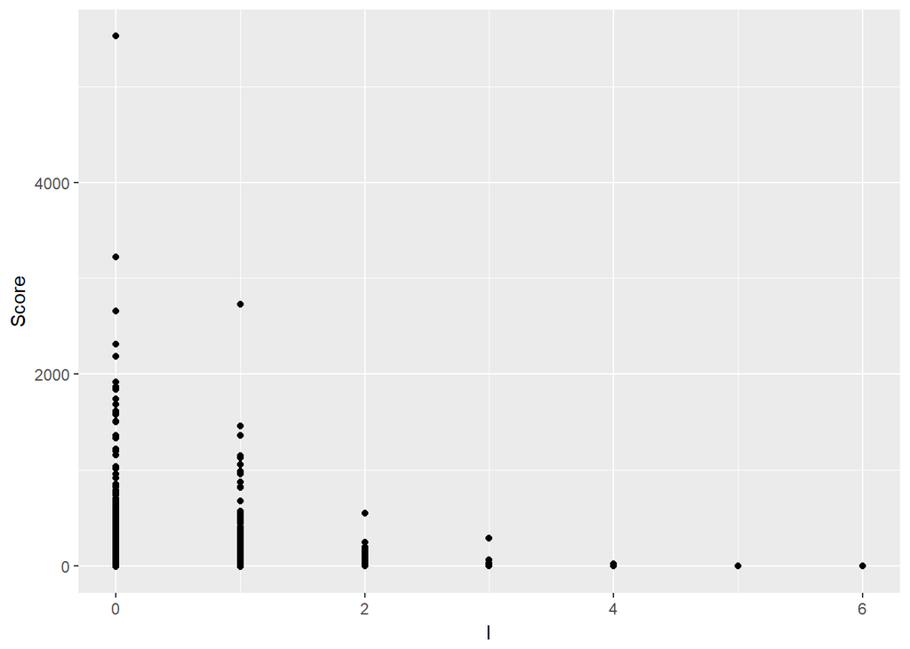

```r
questions<-questions %>% mutate(I=str_count(questions$Title,"I"))
ggplot(data=questions,aes(x=I,y=Score))+geom_point()
```

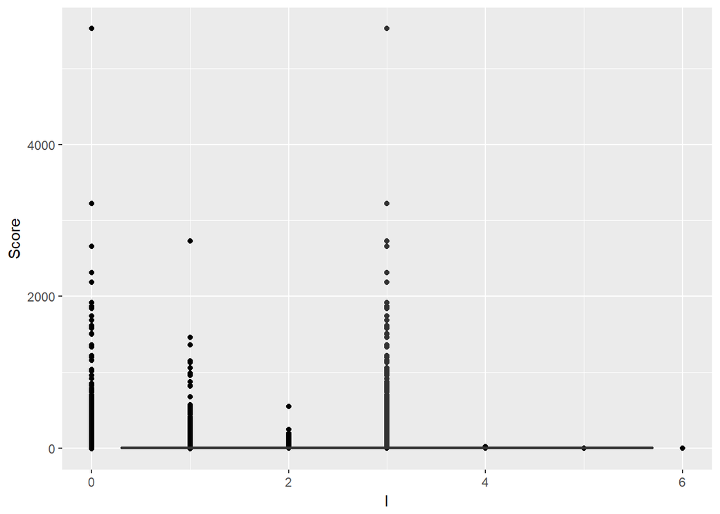

```r
ggplot(data=questions,aes(x=I,y=Score))+geom_point()+geom_boxplot()
```

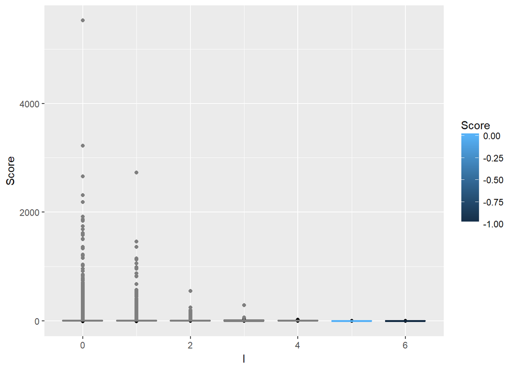

```r
ggplot(data=questions,aes(x=I,y=Score))+geom_point()+geom_boxplot(aes(group=cut_width(I,0.25),color=Score))
```

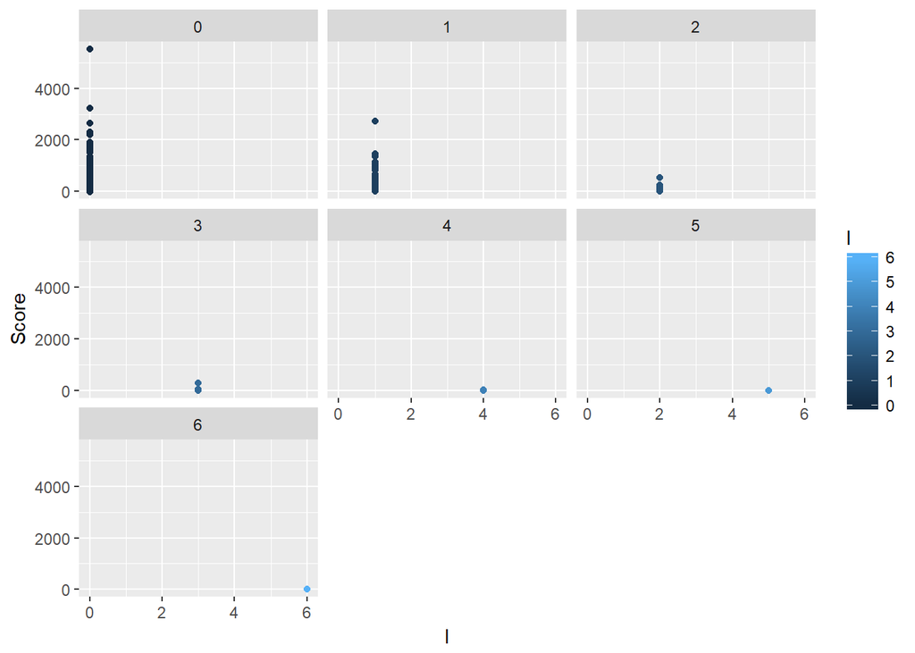

```r
ggplot(data=questions,aes(x=I,y=Score,color=I))+geom_point()+facet_wrap(~I)
```

then I made the ggplot function for the question I was conisder like why the Geom_boxplot function doesnot show up in my expect way, so I use the group=cut_width but it seems not good, then I used the facet_wrap, when we saw the graph I could see that if a person use less “I” in their title they could get a relative high score in the end, but when we saw the boxplot function we could know there is no relation between this two variable cause the density was in the below.

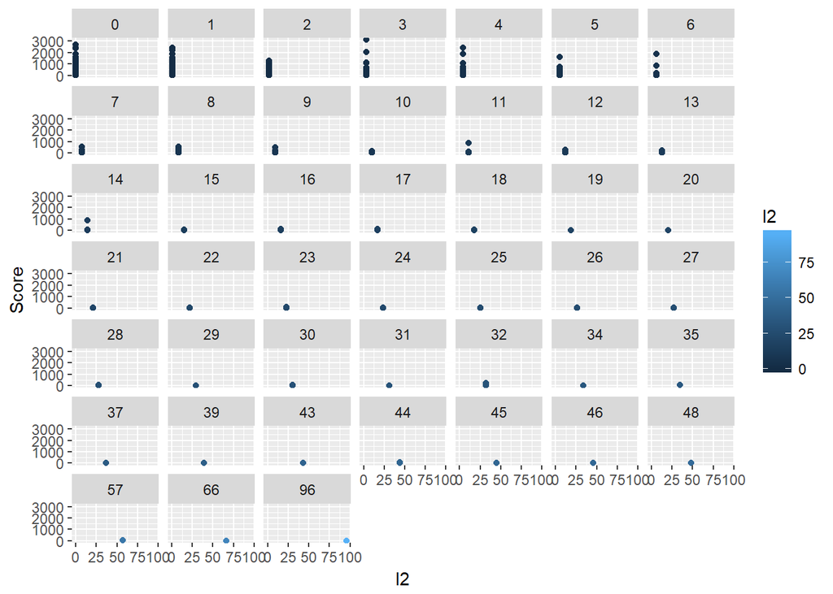

```r
answers<-answers %>% mutate(I2=str_count(answers$Body,"I"))
ggplot(data=answers,mapping=aes(x=I2,y=Score,color=I2))+geom_point()+facet_wrap(~I2)
```

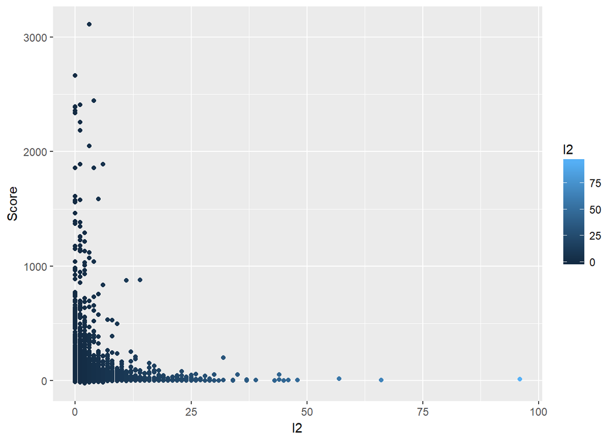

```r
ggplot(data=answers,mapping=aes(x=I2,y=Score,color=I2))+geom_point()
```

# Summary of Who did What

## Lauren

I formatted our final lab document and explained our team results. I also answered questions regarding manners and references. Both required me to use str_detect() and to create a new variable in the data set. I chose to use boxplots for both the question and answer data set because we are concerned with earning a high score on the posts. I also ran a t-test on the answer data to determine if the difference between using a reference and not was significant

## Kaite

I outlined the team questions and modified it. The features that I created are all about the high frequency words appearing in both questions and answers. I narrowed down the range of the scores, and looked for specific words showing in the body of each question and answer. I used str_count to find how many words that contain the same words, and plot them in the certain high range of scores.

## Ryan

I created the code for the team question on timliness vs. score. I also looked at the relationship between length of the title, and score, and the number of yous used in the answer and score. I also wrote the explination section in the team portion.